# K_mean Clustering

Arwa Elnasri

2024-05-12

# upload libraries

```r
library(tidyverse)
```

```r
library(ggplot2)
library(readr)
```

# Upload protein data

```r
protein <- read_csv("~/Machine learning/Unsupervised_learning/K-mean clustering/protein.csv")
head(protein)
```

```
## # A tibble: 6 × 10
##   Country      RedMeat WhiteMeat  Eggs  Milk  Fish Cereals Starch  Nuts `Fr&Veg`
##   <chr>          <dbl>     <dbl> <dbl> <dbl> <dbl>   <dbl>  <dbl> <dbl>    <dbl>
## 1 Albania         10.1       1.4   0.5   8.9   0.2    42.3    0.6   5.5      1.7
## 2 Austria          8.9      14     4.3  19.9   2.1    28      3.6   1.3      4.3
## 3 Belgium         13.5       9.3   4.1  17.5   4.5    26.6    5.7   2.1      4
## 4 Bulgaria         7.8       6     1.6   8.3   1.2    56.7    1.1   3.7      4.2
## 5 Czechoslova…     9.7      11.4   2.8  12.5   2      34.3    5     1.1      4
## 6 Denmark         10.6      10.8   3.7  25     9.9    21.9    4.8   0.7      2.4
```

How many ckuster should we have? # Elbow method:

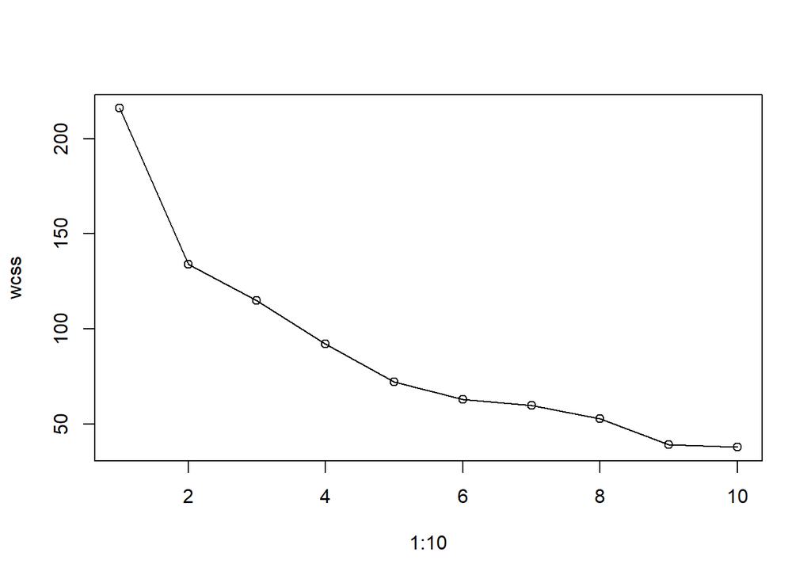

```r
# Select numeric variables and scale them
protein_n<- protein%>% select(-Country)
scaled_p<- scale(protein_n, center= T, scale=T)

# Apply Elbow moethod
set.seed(111)
wcss <- NULL
for(i in 1:10) {
  fit = kmeans(scaled_p, centers = i)
  wcss = c(wcss, fit$tot.withinss)
}
plot(1:10, wcss, type="o")
```

From the Elbow graph, the line in not ideal, there are more than one point where the rate of decrease in WCSS slows down abruptly, forming an “elbow” shape in the plot. For my personal judge, I will select 5 cluster, however it’s as school Assignment with previous requirement. In this Assignment, we are required to build two models, the first model using 3 clusters based on White meat and Red meat consumption. The second model is building a K_means clustering model to cluster European countries into seven groups based on nine protein consumption.

# First: Select Red and White meat

K_means clustering is used to cluster European countries into three groups based on White meat and Red meat consumption. Start by clustering the Red and White meat (p=2) and using 3 clusters (k=3)

```r
protein_rw<- protein %>%
  select(WhiteMeat, RedMeat)


# Scale data
scaled_rw<- scale(protein_rw, center= T, scale=T)

# Cluster into 3 groups using k_means
set.seed(1234)
result_rw<- kmeans(scaled_rw, 3)
```

# Extract some of the information from the fitted model

```r
result_rw
```

```
## K-means clustering with 3 clusters of sizes 12, 5, 8
##
## Cluster means:
##    WhiteMeat    RedMeat
## 1 -0.8764472 -0.4689662
## 2  0.2988565  1.5990065
## 3  1.1278854 -0.2959297
##
## Clustering vector:
##  [1] 1 3 2 1 3 3 3 1 2 1 3 2 1 3 1 3 1 1 1 1 2 2 1 3 1
##
## Within cluster sum of squares by cluster:
## [1] 5.746521 2.960060 3.328067
##  (between_SS / total_SS =  74.9 %)
##
## Available components:
##
## [1] "cluster"      "centers"      "totss"        "withinss"     "tot.withinss"
## [6] "betweenss"    "size"         "iter"         "ifault"
```

```r
# clusters vector:
result_rw$cluster
```

```
##  [1] 1 3 2 1 3 3 3 1 2 1 3 2 1 3 1 3 1 1 1 1 2 2 1 3 1
```

```r
# Clusters means:
result_rw$centers
```

```
##    WhiteMeat    RedMeat
## 1 -0.8764472 -0.4689662
## 2  0.2988565  1.5990065
## 3  1.1278854 -0.2959297
```

```r
# Size of each group
result_rw$size
```

```
## [1] 12  5  8
```

# prepare for visualization

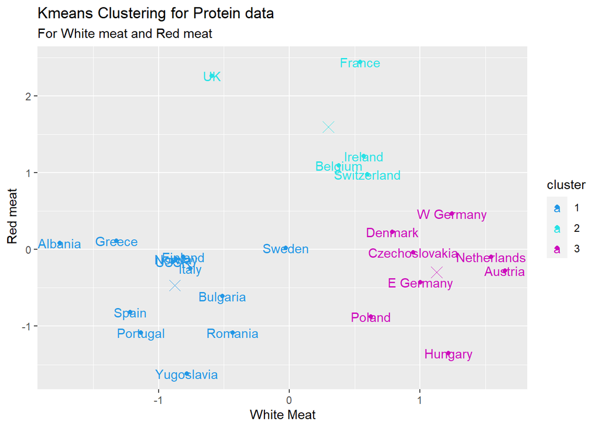

```r
# Add Country and cluster columns to scaled data after change scaled to data frame format
df_scaled_rw<-as.data.frame(scaled_rw)
df_scaled_rw$country<- protein$Country
df_scaled_rw$cluster<- as.factor(result_rw$cluster)

#change centers to data frame format
cluster_centers<-as.data.frame(result_rw$centers)

# visualize K_means Clustering for Protein data For White Meat and Red Meat protein

df_scaled_rw %>% ggplot(aes(WhiteMeat, RedMeat, color=cluster))+
  scale_color_manual(values = 4:6)+             # each cluster in different color
  geom_point()+                                #Add scatter plot
  geom_text(aes(label=country))+              # Add country names
  geom_point(data= cluster_centers, aes(x=WhiteMeat, y= RedMeat,),
             color=4:6,
             shape=4, size=4)+
 labs(title= "Kmeans Clustering for Protein data",
             subtitle ="For White meat and Red meat",
             x="White Meat",
             y=" Red meat")   # add labels
```

# Results Analysis:

’ K_means clustering is used to cluster European countries into three groups -based on White meat and Red meat consumption. The first group (France, UK…) has high consumption of Red meat and middle consumption of white meat. -Both UK and France have rich culinary traditions that include a variety of meat-based dishes. In these countries, certain red meats, such as beef and lamb, are commonly featured in traditional dishes and cuisine. The other cluster (Netherlands, Austria…) includes countries with high white meat consumption compare to red meat That could be due to the availability and affordability of white meat in these countries. The third cluster includes countries with low to average white and red meat consumption.

# Secound: Cluster all nine protein groups and prepare the program to create seven clusters

select nine protein groups

```r
protein_all <- protein %>%
  select(-Country)

# scale nine protein
scaled_all<- scale(protein_all, center=T, scale = T)

# cluster into seven groups using k_means
set.seed(1234)
result_all<- kmeans(scaled_all, 7)
```

# Extract some of the information from the fitted model

```r
result_all
```

```
## K-means clustering with 7 clusters of sizes 4, 3, 4, 4, 4, 2, 4
##
## Cluster means:
##        RedMeat  WhiteMeat       Eggs       Milk        Fish    Cereals
## 1 -0.508801956 -1.1088009 -0.4124850 -0.8320414  0.98191543  0.1300253
## 2  1.525310385  0.1183876  1.3994067  0.5894096 -0.18143344 -0.6634601
## 3 -0.605901566  0.4748136 -0.2782708 -0.3640885 -0.64922214  0.5719474
## 4 -0.083057512  1.3613671  0.8849189  0.1671964 -0.27450135 -0.8062116
## 5  0.006572897 -0.2290150  0.1914789  1.3458748  1.15825462 -0.8722721
## 6  1.709550671  0.5695598  0.2362170  0.6386678 -0.08346722 -0.4918547
## 7 -0.807569986 -0.8719354 -1.5533056 -1.0783324 -1.03863787  1.7200335
##       Starch        Nuts     Fr&Veg
## 1 -0.1842010  1.31088457  1.6292449
## 2  0.7694419 -0.35520960 -0.4080042
## 3  0.6419495 -0.04884971  0.1602082
## 4  0.3665660 -0.86720831 -0.1585451
## 5  0.1676780 -0.95533923 -1.1148048
## 6 -0.2912945 -0.33842275  0.8670088
## 7 -1.4234267  0.99613126 -0.6436044
##
## Clustering vector:
##  [1] 7 4 2 7 3 5 4 5 6 1 3 2 1 4 5 3 1 7 1 5 6 2 3 4 7
##
## Within cluster sum of squares by cluster:
## [1] 18.925874  3.870350 12.227346  5.560527  5.900318  2.939742  8.012133
##  (between_SS / total_SS =  73.4 %)
##
## Available components:
##
## [1] "cluster"      "centers"      "totss"        "withinss"     "tot.withinss"
## [6] "betweenss"    "size"         "iter"         "ifault"
```

```r
# clusters vector
result_all$cluster
```

```
##  [1] 7 4 2 7 3 5 4 5 6 1 3 2 1 4 5 3 1 7 1 5 6 2 3 4 7
```

```r
# clusters means:
result_all$centers
```

```
##        RedMeat  WhiteMeat       Eggs       Milk        Fish    Cereals
## 1 -0.508801956 -1.1088009 -0.4124850 -0.8320414  0.98191543  0.1300253
## 2  1.525310385  0.1183876  1.3994067  0.5894096 -0.18143344 -0.6634601
## 3 -0.605901566  0.4748136 -0.2782708 -0.3640885 -0.64922214  0.5719474
## 4 -0.083057512  1.3613671  0.8849189  0.1671964 -0.27450135 -0.8062116
## 5  0.006572897 -0.2290150  0.1914789  1.3458748  1.15825462 -0.8722721
## 6  1.709550671  0.5695598  0.2362170  0.6386678 -0.08346722 -0.4918547
## 7 -0.807569986 -0.8719354 -1.5533056 -1.0783324 -1.03863787  1.7200335
##       Starch        Nuts     Fr&Veg
## 1 -0.1842010  1.31088457  1.6292449
## 2  0.7694419 -0.35520960 -0.4080042
## 3  0.6419495 -0.04884971  0.1602082
## 4  0.3665660 -0.86720831 -0.1585451
## 5  0.1676780 -0.95533923 -1.1148048
## 6 -0.2912945 -0.33842275  0.8670088
## 7 -1.4234267  0.99613126 -0.6436044
```

# prepare for visualization:

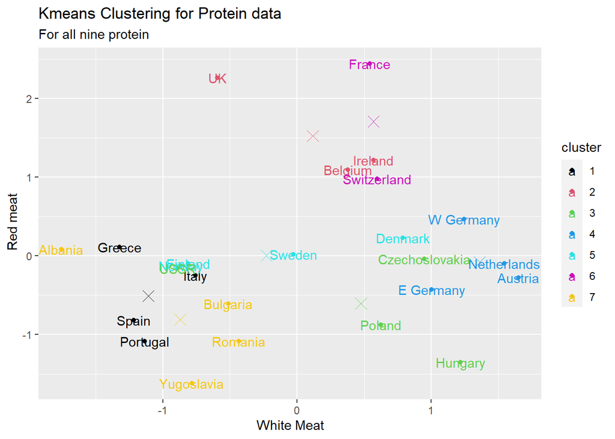

```r
# add country column and cluster to scaled data after change it to data frame format
# Change scaled_all to data frame format
df_scaled_all<- as.data.frame(scaled_all)

# add Country to data
df_scaled_all$country<-protein$Country

# add cluster to data and change it factor
df_scaled_all$cluster<- as.factor(result_all$cluster)

# change center to data frame format
all_center<- as.data.frame(result_all$centers)

# visualize K_means Clustering for Protein data For all nine protein white meat vs red meat
df_scaled_all %>% ggplot(aes(WhiteMeat, RedMeat, color= cluster),)+
  scale_color_manual(values = 1:7)+
  geom_point()+
  geom_text(aes(label=country))+
  geom_point(data=all_center, aes(x=WhiteMeat, y= RedMeat),
             color=1:7, size=4
             , shape=4)+
  labs(title= "Kmeans Clustering for Protein data",
       subtitle ="For all nine protein",
       x="White Meat",
       y=" Red meat")
```

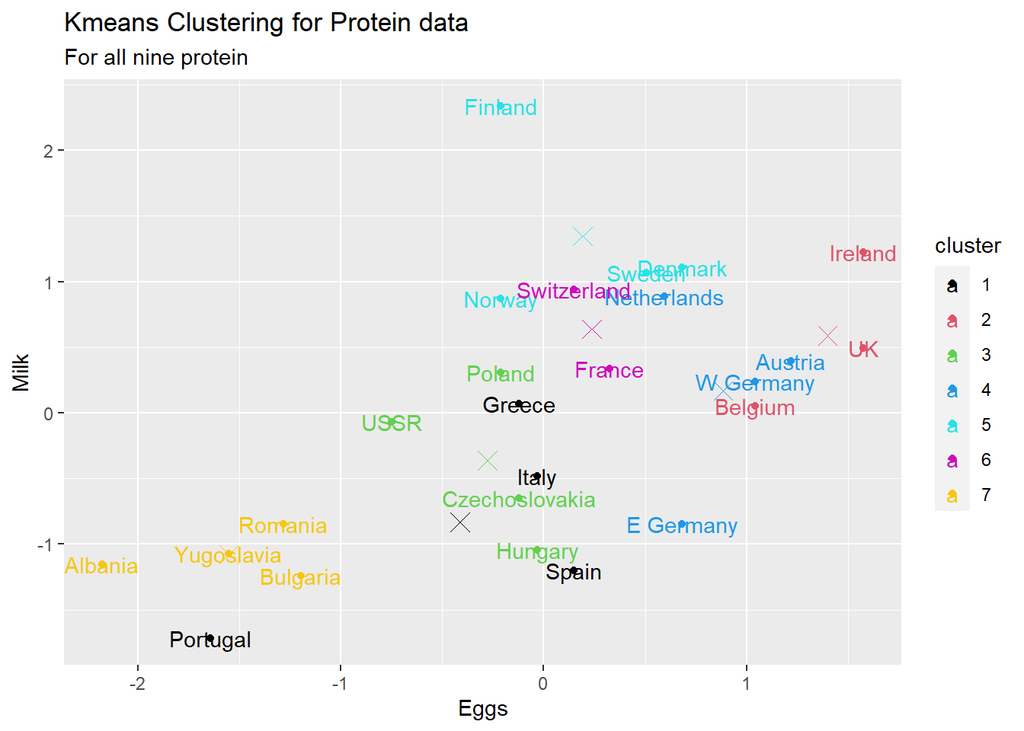

```r
# plot Different variables  Eggs vs milk
df_scaled_all %>% ggplot(aes(x= Eggs ,y= Milk, color= cluster),)+
  scale_color_manual(values = 1:7)+
  geom_point()+
  geom_text(aes(label=country))+
  geom_point(data=all_center, aes(x= Eggs , y= Milk),
             color=1:7, size=4
             , shape=4)+
  labs(title= "Kmeans Clustering for Protein data",
       subtitle ="For all nine protein",
       x=" Eggs ",
       y="Milk")
```

# Results Analysis:

’ K_means clustering is used to cluster European countries into seven groups based on nine protein consumption. The last visualization visualize the seven clusters on a scatter plot of Eggs against Milk Finland has high Milk consumption. Finland has a strong agricultural sector, and dairy farming is well-established. The availability and quality of locally produced dairy products may influence consumption patterns. Ireland and UK have high eggs consumption. Eggs are a staple in traditional British and Irish breakfasts. The “Full English Breakfast” and the “Full Irish Breakfast” typically include eggs as a key component, contributing to the cultural and dietary importance of eggs in the morning meal’